# Proyecto R

Amezcua Caballero Rodrigo, Gómez Mora Héctor Eduardo y Villegas Salvador Kevin Ricardo

13 de Junio del 2018

```r
knitr::opts_chunk$set(echo = TRUE)
```

### Twitter en R

**0. Funciones de R [rtweet](https://www.rdocumentation.org/packages/rtweet/versions/0.6.0)**

Una API (*Application Programming Interface*) que es el conjunto de funciones creadas con el fin de ser utilizadas por otro *software*, nos permite implementar tales funciones en nuestro proyecto sin la necesidad de programarlas de nuevo.

En este caso utilizamos la [**API de Twitter**](https://hipertextual.com/archivo/2014/05/que-es-api/). En éste caso es una *API REST* que es apoyada de **HTTP**(*Hypertext Transfer Protocol*), es decir, nos provee de funciones para poder hacer uso de un servicio web dentro de una aplicación propia, de una manera segura. Al usar ésta **API REST** nuestro proyecto se limita por las funciones dadas, así, la compañia **Twitter** se asegura de lo que podamos hacer.

Para poder usar ésta API necesitamos una cuenta de Twitter

**FUNCIONES**

1. **Buscar tweets**  
   Nos sirve para buscar los tweets y lo que nos regresa es una lista con los tweets encontrados con la refernecia dada. Los parámetros que ésta función recibe son:
   - *referencia* Los tweets que buscaremos.
   - *n* el número de tweets que queremos que se busquen.
   - *retweets* si queremos que incluya los retweets.  
     También puedes agregar unos parámetros llamados:
   - *retryonratelimit* los límites de la tasa de Twitter.
   - *geocode* se buscan los tweets por área *ejemplo: lookup_coords(“usa”), “lang:en”*.
2. **Tweets de transmisión**  
   Muestra aleatoria (aproximadamente 1%) de la transmisión en vivo de los tweets. Los parámetros que ésta función recibe son:
   - *“”* transmite aleatoriamente los tweets.
   - *geocode* transmite los tweets por área.
   - *timeout* el tiempo de duración de los tweets.
   - *file_name* el nombre con el que se guardará los tweets.
   - *parse* se analiza gramaticalmente los tweets.
3. **Conseguir amigos**  
   Busca los amigos de un usuario, y nos regresa una lista de todas las cuentas que sigue un usuario. Los parámetros que ésta función recibe son:
   - *usuario* el nombre del usuario.
4. **Consigue seguidores**  
   Busca los seguidores de un usuario, y nos regresa una lista de las cuentas que siguen a un usuario. Los parámetros que ésta función recibe son:
   - *usuario* el nombre del usuario.
   - *n* el tamaño de la lista, es decir, el número de cuentas que siguen a un usuario.
   - *retryonratelimit* los límites de la tasa de twitter.
5. **Obtenga líneas de tiempo**  
   Obtener los tweets más recientes, y regresa una lista con tales tweets. Los parámetros que ésta función recibe son:
   - *referencia* la referencia a buscar para conseguir los tweets más recientes.
   - *n* el número de tweets que se buscarán.
6. **Obtener favoritos**  
   Obtiene los estados favoritos más recientes. Regresa los tweets favoritos. Los parámetros que ésta función recibe son:
   - *referencia* la referencia a buscar los tweets favoritos.
   - *n* el número de tweets que se buscarán.
7. **Buscar usuarios**  
   Busca los usuarios con el hashtag en su biografía del perfil, y nos regresa una lista con los usuarios. Los parámetros que ésta función recibe son:
   - *hashtag* el hashtag a buscar en la biografía de perfil de los usuarios.
   - *n* el número de tweets que se buscarán.
8. **Obtener tendencias**  
   Busca lo que esá en tendencia y lo que regresa lo que está en tendencia en algún estado. Los parámetros que ésta función recibe son:
   - *estado* el nombre del estado a buscar lo que está en tendencia.

**1. Instale y cargue la librería rtweet.**

Para instalar la librería, nos dirigimos a la terminal e introducimos el siguiente código.

```r
install.packages("rtweet")
```

Para cargar la librería es el siguiente código

```r
library(rtweet)
```

**2. Creamos una `Twitter App`.**

[figure not shown]

**3. `Twitter` token.**

De nuestra `App Twitter` obtendremos los datos para poder crear nuestro token.

```r
#Declaramos las variables para poder crear nuestro token y poder hacer la conexión.
appname <- "Proyecto de R"
consumer_key <- "dS1EoI0pt0uWL5dTIom7hYJFV"
consumer_secret <- "E9GflYo2OhQLdl7xHqasaUpX32UTiq6Ued0A5wDxbxVYrYxq5W"

#Creamos nuestro Token para poder tener acceso a Twitter
create_token(app = appname, consumer_key = consumer_key, consumer_secret = consumer_secret)
```

**4. Busqueda de tweets.**

Ya que tenemos el acceso a `Twitter` buscamos los tweets que contienen el `#UNAM` e imprimos los primeros 10.

```r
unam <- search_tweets("#UNAM", n = 2000, include_rts = FALSE)
```

```
## Searching for tweets...
```

```
## Finished collecting tweets!
```

```r
head(unam,10)
```

```
## # A tibble: 10 x 42
##    status_id  created_at          user_id screen_name text          source
##    <chr>      <dttm>              <chr>   <chr>       <chr>         <chr>
##  1 100665293… 2018-06-12 21:42:16 140065… noticiasde… "#Elecciones… Twitt…
##  2 100665041… 2018-06-12 21:32:15 144214… Marcross10  #UNAM, la un… Twitt…
##  3 100664984… 2018-06-12 21:30:00 122074… ElitInfra   "EMI, es un … Tweet…
##  4 100664860… 2018-06-12 21:25:04 705480… RevistaObr… Ciudad Unive… Hoots…
##  5 100664534… 2018-06-12 21:12:07 135995… PenelopeCHG Amo la alber… Twitt…
##  6 100664443… 2018-06-12 21:08:31 164663… Diannekorin #AnayaPorLav… Twitt…
##  7 100664242… 2018-06-12 21:00:31 644563… Ciencia_UN… #UNAM desarr… Hoots…
##  8 100664233… 2018-06-12 21:00:08 308191… fanbolero   "El español … Twitt…
##  9 100664232… 2018-06-12 21:00:07 130246… cceessaarr… "PODCAST Cic… Faceb…
## 10 100664194… 2018-06-12 20:58:37 998666… Liz_Garrid… "Tan bonita.… Twitt…
## # ... with 36 more variables: reply_to_status_id <chr>,
## #   reply_to_user_id <chr>, reply_to_screen_name <chr>, is_quote <lgl>,
## #   is_retweet <lgl>, favorite_count <int>, retweet_count <int>,
## #   hashtags <list>, symbols <list>, urls_url <list>, urls_t.co <list>,
## #   urls_expanded_url <list>, media_url <list>, media_t.co <list>,
## #   media_expanded_url <list>, media_type <list>, ext_media_url <list>,
## #   ext_media_t.co <list>, ext_media_expanded_url <list>,
## #   ext_media_type <lgl>, mentions_user_id <list>,
## #   mentions_screen_name <list>, lang <chr>, quoted_status_id <chr>,
## #   quoted_text <chr>, retweet_status_id <chr>, retweet_text <chr>,
## #   place_url <chr>, place_name <chr>, place_full_name <chr>,
## #   place_type <chr>, country <chr>, country_code <chr>,
## #   geo_coords <list>, coords_coords <list>, bbox_coords <list>
```

**5. Buscando usuarios.**

```r
#Vector para guardar los nombres de los tweets buscados.
users <- c(unam$screen_name[1:10])
#Vector de listas con las listas de los estados favoritos de cada usuario.


#ASignamos el nombre del usuario que ha recibido mas favoritos y así usarla.
nameUser <- unam$screen_name[21]
```

**6. Ubicación geográfica.**

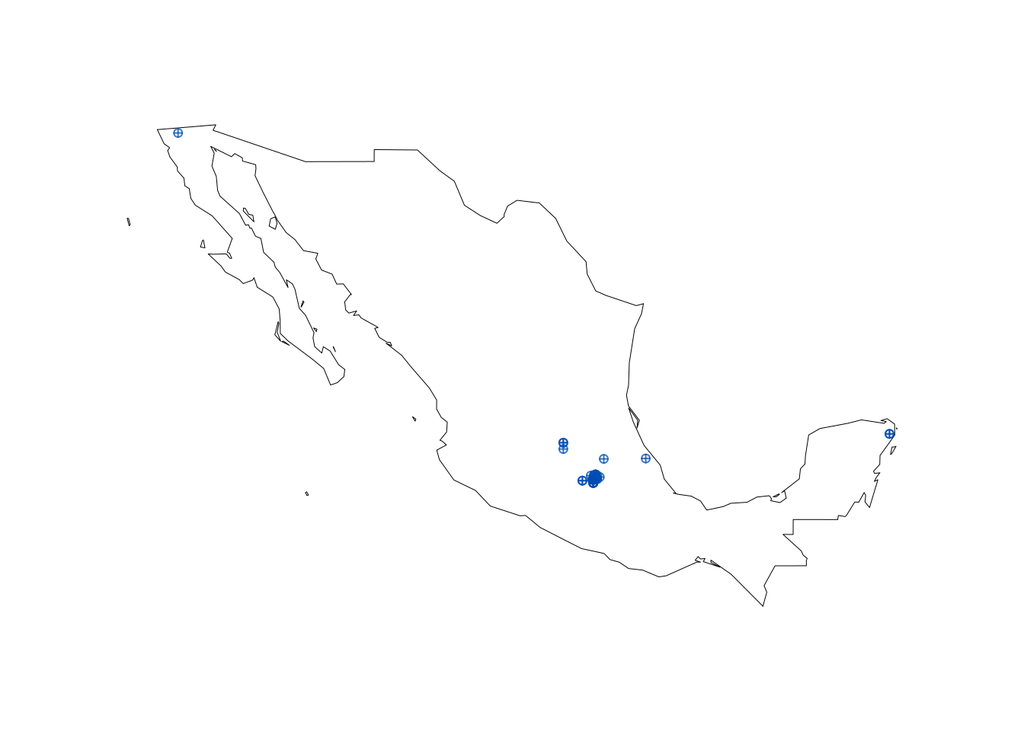

```r
#Cargamos la librería maps
library(maps)
##Creamos lat_lon para obtener la ubcicación de los tweets
rt <- lat_lng(unam)

## plot state boundaries
maps::map("world","mexico", lwd = .50)

## plot lat and lng points onto state map
with(rt, points(lng, lat, pch = 10, cex = .75, col = rgb(0, .3, .7, .75)))
```

**7. Tweets disponibles.**

```r
timeline <- get_timeline(nameUser)
timeline
```

```
## # A tibble: 100 x 42
##    status_id  created_at          user_id screen_name text          source
##  * <chr>      <dttm>              <chr>   <chr>       <chr>         <chr>
##  1 100665318… 2018-06-12 21:43:16 249693… Milenio     Ella es Lore… Tweet…
##  2 100665254… 2018-06-12 21:40:43 249693… Milenio     "RT @laafici… Tweet…
##  3 100665072… 2018-06-12 21:33:31 249693… Milenio     "#ENVIVO por… Tweet…
##  4 100665050… 2018-06-12 21:32:38 249693… Milenio     https://t.co… Peris…
##  5 100664990… 2018-06-12 21:30:15 249693… Milenio     Con su vesti… Tweet…
##  6 100664833… 2018-06-12 21:24:00 249693… Milenio     ▶VIDEO | ¿Es… Tweet…
##  7 100664807… 2018-06-12 21:22:57 249693… Milenio     #ÚLTIMAHORA … Tweet…
##  8 100664732… 2018-06-12 21:20:00 249693… Milenio     "▶ VIDEO | \… Tweet…
##  9 100664632… 2018-06-12 21:16:01 249693… Milenio     "\"Usted más… Tweet…
## 10 100664583… 2018-06-12 21:14:05 249693… Milenio     "\"Mira cómo… Tweet…
## # ... with 90 more rows, and 36 more variables: reply_to_status_id <lgl>,
## #   reply_to_user_id <lgl>, reply_to_screen_name <lgl>, is_quote <lgl>,
## #   is_retweet <lgl>, favorite_count <int>, retweet_count <int>,
## #   hashtags <list>, symbols <list>, urls_url <list>, urls_t.co <list>,
## #   urls_expanded_url <list>, media_url <list>, media_t.co <list>,
## #   media_expanded_url <list>, media_type <list>, ext_media_url <list>,
## #   ext_media_t.co <list>, ext_media_expanded_url <list>,
## #   ext_media_type <lgl>, mentions_user_id <list>,
## #   mentions_screen_name <list>, lang <chr>, quoted_status_id <chr>,
## #   quoted_text <chr>, retweet_status_id <chr>, retweet_text <chr>,
## #   place_url <chr>, place_name <chr>, place_full_name <chr>,
## #   place_type <chr>, country <chr>, country_code <chr>,
## #   geo_coords <list>, coords_coords <list>, bbox_coords <list>
```

**8. Gráfico.**

[figure not shown]

```r
## get user IDs of accounts followed by CNN
tmls <- get_timelines(c("cnn", "BBCWorld", "foxnews"), n = 3200)

## plot the frequency of tweets for each user over time
tmls %>%
  dplyr::filter(created_at > "2017-10-29") %>%
  dplyr::group_by(screen_name) %>%
  ts_plot("days", trim = 1L) +
  ggplot2::geom_point() +
  ggplot2::theme_minimal() +
  ggplot2::theme(
    legend.title = ggplot2::element_blank(),
    legend.position = "bottom",
    plot.title = ggplot2::element_text(face = "bold")) +
  ggplot2::labs(
    x = NULL, y = NULL,
    title = "Frequency of Twitter statuses posted by news organization",
    subtitle = "Twitter status (tweet) counts aggregated by day from October/November 2017",
    caption = "\nSource: Data collected from Twitter's REST API via rtweet"
  )
```

**9. Obtener amigos.**

Obtenemos las cuentas de los amigos del usuario del paso 5.

```r
friend <- get_friends(nameUser)
friend
```

```
## # A tibble: 145 x 2
##    user    user_id
##    <chr>   <chr>
##  1 Milenio 104332277
##  2 Milenio 149295312
##  3 Milenio 16676396
##  4 Milenio 97017966
##  5 Milenio 64429737
##  6 Milenio 139595087
##  7 Milenio 42691116
##  8 Milenio 34313570
##  9 Milenio 965674731763531776
## 10 Milenio 2788136904
## # ... with 135 more rows
```

```r
da <- users_data(unam)
da
```

```
## # A tibble: 1,280 x 20
##    user_id  name   screen_name  location description       url   protected
##    <chr>    <chr>  <chr>        <chr>    <chr>             <chr> <lgl>
##  1 1400651… Notic… noticiasdel6 Posadas… Canal de Noticia… http… FALSE
##  2 1442142… Marco… Marcross10   Ciudad … Ing.Civil,..:Tal… <NA>  FALSE
##  3 1220746… Elit … ElitInfra    México,… Expertos integra… http… FALSE
##  4 70548028 Obras… RevistaObras México   45 años con lo m… http… FALSE
##  5 1359953… Penél… PenelopeCHG  Ciudad … Oficial de Incid… <NA>  FALSE
##  6 1646637… ターゲット… Diannekorin  ""       Siendo yo y solo… <NA>  FALSE
##  7 64456342 Cienc… Ciencia_UNAM México   Síguenos y descu… http… FALSE
##  8 3081911… Fanbo… fanbolero    México   TU DOSIS DE FUTB… http… FALSE
##  9 1302462… Psicó… cceessaarrm… ""       ""                <NA>  FALSE
## 10 9986668… Lizet… Liz_GarridoS Ciudad … Tu vara y tu cay… <NA>  FALSE
## # ... with 1,270 more rows, and 13 more variables: followers_count <int>,
## #   friends_count <int>, listed_count <int>, statuses_count <int>,
## #   favourites_count <int>, account_created_at <dttm>, verified <lgl>,
## #   profile_url <chr>, profile_expanded_url <chr>, account_lang <chr>,
## #   profile_banner_url <chr>, profile_background_url <chr>,
## #   profile_image_url <chr>
```

**11. Tendencias.**

Buscamos primero cuales son las tendencias disponibles.

```r
available <- trends_available()
available
```

```
## # A tibble: 467 x 8
##    name       url      parentid country woeid countryCode  code place_type
##  * <chr>      <chr>       <int> <chr>   <int> <chr>       <int> <chr>
##  1 Worldwide  http://…        0 ""          1 <NA>           19 Supername
##  2 Winnipeg   http://… 23424775 Canada   2972 CA              7 Town
##  3 Ottawa     http://… 23424775 Canada   3369 CA              7 Town
##  4 Quebec     http://… 23424775 Canada   3444 CA              7 Town
##  5 Montreal   http://… 23424775 Canada   3534 CA              7 Town
##  6 Toronto    http://… 23424775 Canada   4118 CA              7 Town
##  7 Edmonton   http://… 23424775 Canada   8676 CA              7 Town
##  8 Calgary    http://… 23424775 Canada   8775 CA              7 Town
##  9 Vancouver  http://… 23424775 Canada   9807 CA              7 Town
## 10 Birmingham http://… 23424975 United… 12723 GB              7 Town
## # ... with 457 more rows
```

```r
trends <- get_trends(available$name[7])
trends
```

```
## # A tibble: 50 x 9
##    trend   url           promoted_content query   tweet_volume place woeid
##  * <chr>   <chr>         <lgl>            <chr>          <int> <chr> <int>
##  1 #1000W… http://twitt… NA               %23100…           NA Edmo…  8676
##  2 Alberta http://twitt… NA               Alberta        10303 Edmo…  8676
##  3 #yegwx  http://twitt… NA               %23yeg…           NA Edmo…  8676
##  4 #ABRoa… http://twitt… NA               %23ABR…           NA Edmo…  8676
##  5 #Thank… http://twitt… NA               %23Tha…        13869 Edmo…  8676
##  6 #E32018 http://twitt… NA               %23E32…       719308 Edmo…  8676
##  7 Trump   http://twitt… NA               Trump        4462580 Edmo…  8676
##  8 La CAQ  http://twitt… NA               %22La+…           NA Edmo…  8676
##  9 Time W… http://twitt… NA               %22Tim…        30340 Edmo…  8676
## 10 Smash   http://twitt… NA               Smash         451001 Edmo…  8676
## # ... with 40 more rows, and 2 more variables: as_of <dttm>,
## #   created_at <dttm>
```